# 18. praktikum

### Tunnuste olulisus

**Tunnuste olulisust** (permutatsiooniolulisust) saab `cforest`-objektist kätte funktsiooniga `varimp()`. `cforest` väljastab ainult tunnuste permutatsiooniolulisuse.

```r
# Tunnuste olulisus
imps <- varimp(mets_kat_cf)
imps
```

```
##        TR_liik tegusõna_klass   LM_mobiilsus LM_komplekssus  LM_pikkus_log
##     0.06310928     0.06106395     0.32997251     0.06779852     0.04513624
##       sõnajärg      murderühm
##     0.01046454     0.08351061
```

```r
# Teeme olulisustest andmetabeli
imps_df <- data.frame(olulisus = imps, # väärtused tulpa "olulisus"
                      tunnus = names(imps), # tunnuste nimed tulpa "tunnus"
                      row.names = NULL) # reanimesid pole vaja
head(imps_df)
```

```
##     olulisus         tunnus
## 1 0.06310928        TR_liik
## 2 0.06106395 tegusõna_klass
## 3 0.32997251   LM_mobiilsus
## 4 0.06779852 LM_komplekssus
## 5 0.04513624  LM_pikkus_log
## 6 0.01046454       sõnajärg
```

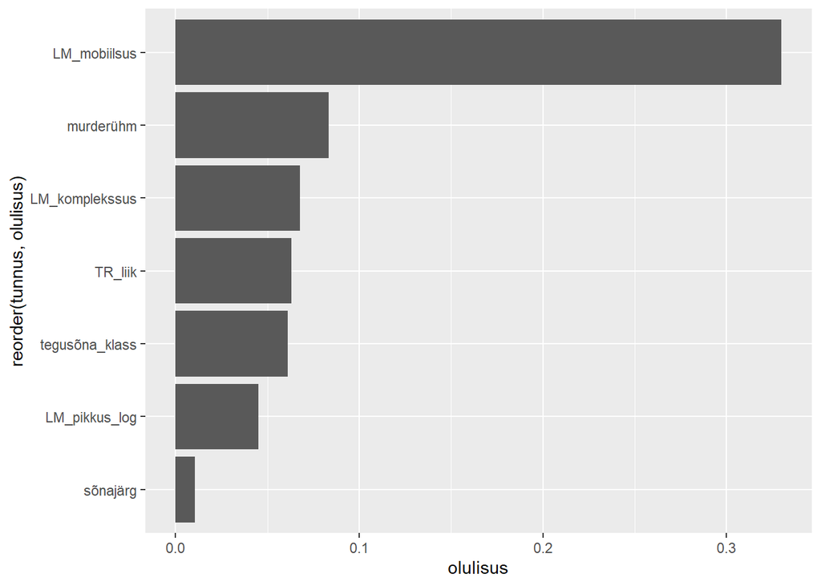

```r
# Teeme joonise
ggplot(data = imps_df,
       aes(y = reorder(tunnus, olulisus), x = olulisus)) +
  geom_col()
```

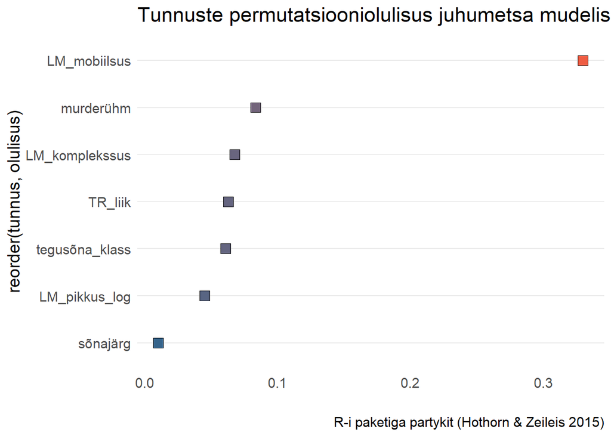

```r
# Või
ggplot(data = imps_df,
       aes(y = reorder(tunnus, olulisus),
           x = olulisus,
           fill = olulisus)) +
  geom_point(size = 4, shape = 22, show.legend = FALSE) +
  scale_fill_gradient(low = "steelblue4", high = "tomato2") +
  labs(x = "",
       title = "Tunnuste permutatsiooniolulisus juhumetsa mudelis",
       caption = "R-i paketiga partykit (Hothorn & Zeileis 2015)") +
  theme_minimal() +
  theme(text = element_text(size = 14),
        panel.grid.minor = element_blank(),
        panel.grid.major.x = element_blank())
```

Tavaline permutatsiooniolulisus võib ülehinnata omavahel seotud/korreleeruvate seletavate tunnuste olulisust. Selle vältimiseks on `partykit`-paketis võimalik hinnata tunnuste **tingimuslikku olulisust** (*conditional importance*, `conditional = TRUE`). Kuna see on arvutusmahukas protsess ja võtab omajagu aega, paneme siia ainult koodi (soovi korral võid enda arvutis läbi jooksutada, aga arvesta selle andmestiku puhul tavalises sülearvutis vähemalt tunnise ajakuluga).

```r
# Tunnuste tingimuslik olulisus (NB! võib võtta kaua aega)
imps_cond <- varimp(mets_kat_cf, conditional = TRUE)
imps_cond

# Teeme olulisusest andmetabeli
imps_cond_df <- data.frame(olulisus = imps_cond, tunnus = names(imps_cond), row.names = NULL)
head(imps_cond_df)

# Teeme joonise
ggplot(data = imps_cond_df,
       aes(y = reorder(tunnus, olulisus), x = olulisus)) +
  geom_point(aes(fill = olulisus), size = 4, shape = 22, show.legend = FALSE) +
  scale_fill_gradient(low = "steelblue4", high = "tomato2") +
  labs(x = "",
       title = "Tunnuste tingimuslik permutatsiooniolulisus\njuhumetsa mudelis",
       caption = "R-i paketiga partykit") +
  theme_minimal() +
  theme(text = element_text(size = 14),
        panel.grid.minor = element_blank(),
        panel.grid.major.x = element_blank())
```

Kolmas tunnuste olulisuse liik on nn **AUC**-olulisus, mis sobib paremini siis, [kui uuritava tunnuse üks väärtus on andmestikus oluliselt sagedasem kui teine/teised](https://bmcbioinformatics.biomedcentral.com/articles/10.1186/1471-2105-14-119). Selle kasutamiseks on aga puu vaja ehitada mitte `partykit` paketiga, vaid hoopis `party` paketiga.

```r
#install.packages(c("party", "varImp"))

# desaktiveerime paketi "partykit"
detach("package:partykit", unload = T)

# laadime paketi "party"
library(party)
set.seed(100)
mets_kat_cf_party <- cforest(cx ~ TR_liik + tegusõna_klass + LM_mobiilsus + LM_komplekssus + LM_pikkus_log + sõnajärg + murderühm,
                             data = dat,
                             controls = cforest_control(ntree = 100, mtry = 2))
imps_auc <- varImp::varImpAUC(mets_kat_cf_party)

# Teeme olulisusest andmetabeli
imps_auc_df <- data.frame(olulisus = imps_auc, tunnus = names(imps_auc), row.names = NULL)
head(imps_auc_df)
```

```
##        olulisus         tunnus
## 1  0.0063928488        TR_liik
## 2  0.0160126690 tegusõna_klass
## 3  0.0799388770   LM_mobiilsus
## 4  0.0169939519 LM_komplekssus
## 5  0.0035859200  LM_pikkus_log
## 6 -0.0006759645       sõnajärg
```

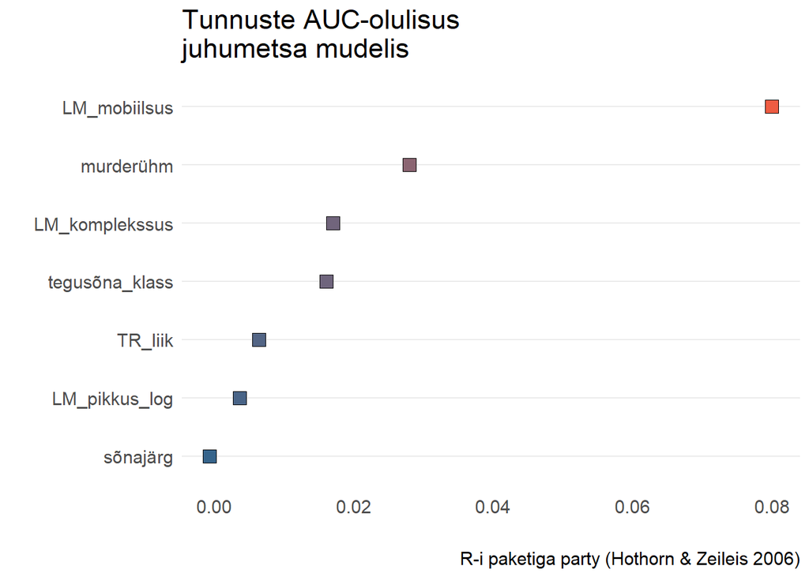

```r
# Teeme joonise
ggplot(data = imps_auc_df,
       aes(y = reorder(tunnus, olulisus), x = olulisus)) +
  geom_point(aes(fill = olulisus), size = 4, shape = 22, show.legend = FALSE) +
  scale_fill_gradient(low = "steelblue4", high = "tomato2") +
  labs(x = "", y = "",
       title = "Tunnuste AUC-olulisus\njuhumetsa mudelis",
       caption = "R-i paketiga party (Hothorn & Zeileis 2006)") +
  theme_minimal() +
  theme(text = element_text(size = 14),
        panel.grid.minor = element_blank(),
        panel.grid.major.x = element_blank())
```

```r
detach("package:party", unload = T)
```

## Juhumetsade visualiseerimine

Üldjuhul kasutatakse juhumetsi kõige olulisemate tunnuste väljaselgitamiseks ning parima mudeli tegemiseks, mida saaks praktikas uute vaatluste klasside/väärtuste ennustamiseks kasutada. Juhumets on oma olemuselt nn musta kasti mudel ega võimalda vaadata metsa sisse samamoodi nagu üksikute puude puhul. Seega ei näe me, mil moel täpselt mingid tunnused uuritava tunnuse väärtust mõjutavad.

On siiski mõned visualiseerimistehnikad, mis võimaldavad seletavate tunnuste üldmõjusid ja interaktsioone visualiseerida sarnaselt regressioonimudelitega. Üheks selliseks tehnikaks on nn **osalise sõltuvuse graafikud** (*partial dependence plots*), mis visualiseerivad korraga ühe seletava tunnuse (või tunnustevahelise interaktsiooni) mõju uuritavale tunnusele. Põhimõtteliselt on tegemist sama asjaga, mida nägime regressioonimudelite juures *marginal effects* nime all, kus mudeli abil ennustatakse mingites tüüpkontekstides iga seletava tunnuse väärtusest sõltuvalt mingit sündmuse toimumise tõenäosust.

Vaatame funktsiooni **`plotmo()`** võimalusi samanimelises [paketis](https://cran.r-project.org/web/packages/plotmo/plotmo.pdf).  
Selle kõige lihtsamas versioonis hoitakse ühe seletava tunnuse mõju hindamisel **teiste arvuliste seletavate tunnuste väärtused nende mediaani peal** ning **kategoriaalsete tunnuste väärtused nende kõige sagedamal/tüüpilisemal tasemel (= moodi peal)**. Määrates funktsioonis argumendi `trace = 1`, näitab funktsioon ka seda, millised need väärtused täpsemalt on. Neid väärtusi saab muuta funktsioonis argumentidega `grid.func` ja `grid.levels` (vt lähemalt paketi dokumentatsioonist). `plotmo` paketi tegijad ise nimetavad seda ka “vaese mehe osalise sõltuvuse graafikuks”. See on kiirem ning annab enam-vähem ülevaate tunnustevahelistest sõltuvussuhetest.

```
## variable importance: TR_liik tegusõna_klass LM_mobiilsus LM_komplekssus LM_pikkus_log sõnajärg murderühm
## stats::predict(cforest.object, data.frame[3,7], type="response")
## stats::fitted(object=cforest.object)
## got model response from model.frame(cx ~ TR_liik + tegusõna_klass + LM_mo...,
##                                     data=object$data, na.action="na.fail")
```

```
##
##  plotmo grid:    TR_liik tegusõna_klass LM_mobiilsus LM_komplekssus
##            nimisõnafraas     olemisverb   staatiline       lihtsõna
##  LM_pikkus_log sõnajärg murderühm
##              1    tr_lm      Kesk
```

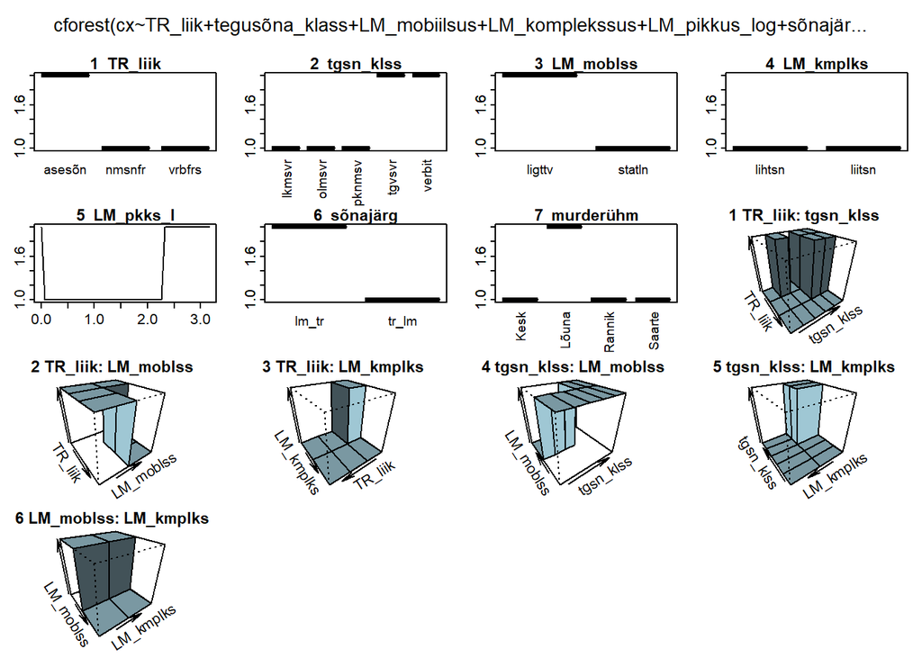

```r
# install.packages("plotmo")
library(plotmo)

plotmo(object = mets_kat_cf,
       trace = 1)
```

Vaikimisi teeb `plotmo` graafiku, mis ennustab uuritava tunnuse **klasse** (`type = "response"`). Seega tähendab “1” meie andmestiku puhul seda, et kasutatakse *ade*-konstruktsiooni, ning “2” seda, et kasutatakse *peal*-konstruktsiooni (juhul, kui hoida kõik teised tunnused kindlal tasemel!).

Ilmselt oleks aga informatiivsem vaadata graafikuid mitte ennustatud klasside, vaid **tõenäosuste** põhjal, kuna see võimaldab paindlikumat analüüsi. Selleks lisame funktsiooni argumendi `type = "prob"`.

```
## variable importance: TR_liik tegusõna_klass LM_mobiilsus LM_komplekssus LM_pikkus_log sõnajärg murderühm
## stats::predict(cforest.object, data.frame[3,7], type="prob")
## stats::fitted(object=cforest.object)
## set nresponse=2
## nresponse=2 but for plotmo_y using nresponse=1 because ncol(y) == 1
## got model response from model.frame(cx ~ TR_liik + tegusõna_klass + LM_mo...,
##                                     data=object$data, na.action="na.fail")
```

```
##
##  plotmo grid:    TR_liik tegusõna_klass LM_mobiilsus LM_komplekssus
##            nimisõnafraas     olemisverb   staatiline       lihtsõna
##  LM_pikkus_log sõnajärg murderühm
##              1    tr_lm      Kesk
```

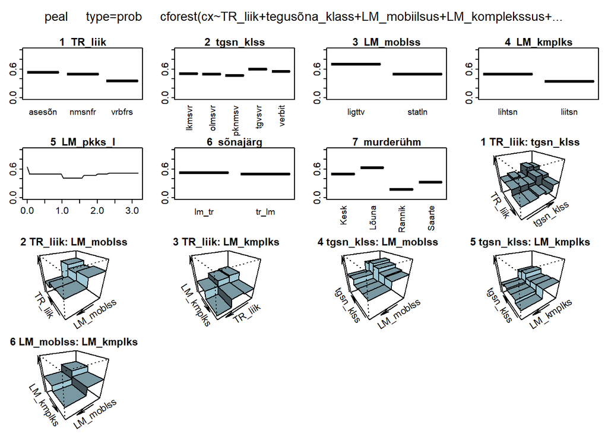

```r
plotmo(object = mets_kat_cf,
       trace = 1,
       type = "prob")
```

Näeme, et tõenäosustena esitatuna ei ole erinevused *ade* ja *peal*-konstruktsioonide kasutamises üldse nii suured kui kategoorilises esituses.

Kui tahaksime kuvada interaktsioone 3D-graafikute asemel näiteks toonide kaudu, võime kasutada funktsioonis lisaks argumenti `type2 = "image"`, kus tumedamad toonid näitavad väiksemat tõenäosust ning heledamad suuremat.

```
## variable importance: TR_liik tegusõna_klass LM_mobiilsus LM_komplekssus LM_pikkus_log sõnajärg murderühm
## stats::predict(cforest.object, data.frame[3,7], type="prob")
## stats::fitted(object=cforest.object)
## set nresponse=2
## nresponse=2 but for plotmo_y using nresponse=1 because ncol(y) == 1
## got model response from model.frame(cx ~ TR_liik + tegusõna_klass + LM_mo...,
##                                     data=object$data, na.action="na.fail")
```

```
##
##  plotmo grid:    TR_liik tegusõna_klass LM_mobiilsus LM_komplekssus
##            nimisõnafraas     olemisverb   staatiline       lihtsõna
##  LM_pikkus_log sõnajärg murderühm
##              1    tr_lm      Kesk
```

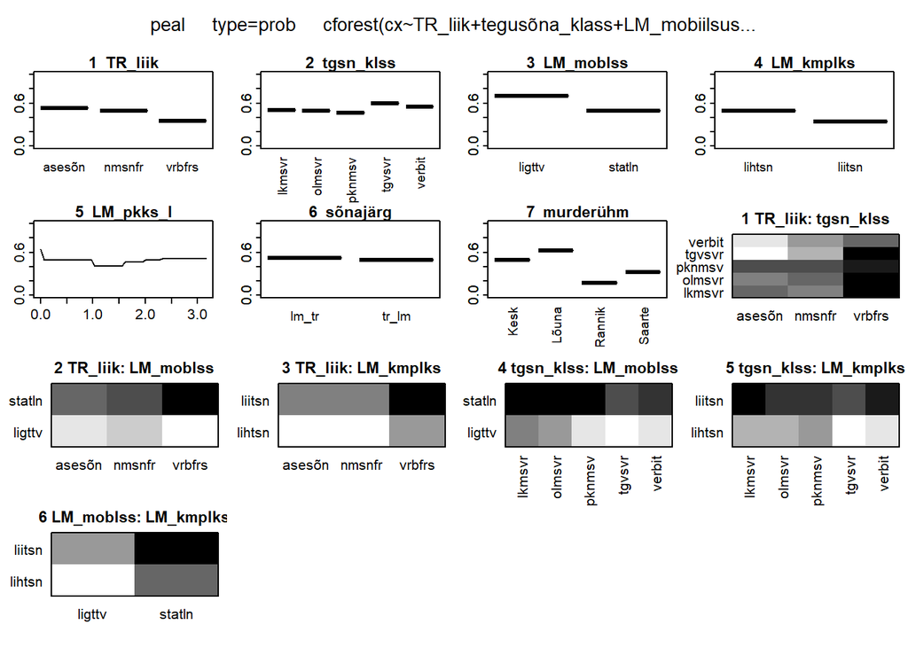

```r
plotmo(object = mets_kat_cf,
       trace = 1,
       type = "prob",
       type2 = "image")
```

Võime valida ka ainult kindlad graafikud, mida näha tahame. Peamõjude valimiseks saab kasutada argumenti `degree1` ning interaktsioonide jaoks argumenti `degree2`.

```r
plotmo(object = mets_kat_cf,
       trace = 1,
       type = "prob",
       type2 = "image",
       degree1 = c("TR_liik", "LM_mobiilsus"),
       degree2 = c("TR_liik", "LM_mobiilsus"))
```

[output not shown]

`plotmo`-paketiga saab teha ka n-ö päris osalise sõltuvuse graafikuid, kus iga konkreetse seletava tunnuse juures kõikide teiste seletavate tunnuste tasemete mõju keskmistatakse selle asemel, et määrata lihtsalt läbivalt mingi fikseeritud taustakontekst. Need graafikud annavad seega pisut adekvaatsema pildi üksikute seletavate tunnuste marginaalsest mõjust, kuna ei arvesta ainult mingit üht spetsiifilist konteksti. Osalise sõltuvuse graafikute jaoks määrame argumendi `pmethod` väärtuseks `partdep`. Kuna tunnuseid on mitu ning meetod komplekssem ja arvutusmahukam, läheb sellise graafiku tegemiseks ka rohkem aega. Kuvame siin seega ressursi kokkuhoiu mõttes ainult peamõjud ning jätame interaktsioonid kuvamata (`degree2 = FALSE`).

```r
plotmo(object = mets_kat_cf,
       trace = 1,
       pmethod = "partdep",
       type = "prob",
       degree2 = FALSE)
```

[output not shown]

Osalise sõltuvuse graafikute tegemiseks on ka teisi pakette, nt `pdp`, `ICEbox` ja `edarf`. Ka `randomForest`-paketil on tegelikult sisseehitatud `partialPlot()` funktsioon, ent sellega saab korraga kuvada ainult üht tunnust ning y-teljel ei ole kuvatud mitte tõnäosused, vaid tunnuse väärtuste suhteline mõju uuritavale tunnusele (negatiivsel poolel “peal” esinemisele, positiivsel poolel “ade” esinemisele).

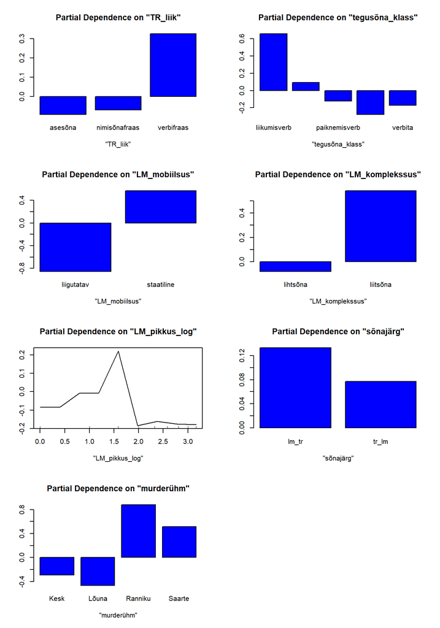

```r
par(mfrow = c(4,2))
randomForest::partialPlot(mets_kat_rf, x.var = "TR_liik", pred.data = dat)
randomForest::partialPlot(mets_kat_rf, x.var = "tegusõna_klass", pred.data = dat)
randomForest::partialPlot(mets_kat_rf, x.var = "LM_mobiilsus", pred.data = dat)
randomForest::partialPlot(mets_kat_rf, x.var = "LM_komplekssus", pred.data = dat)
randomForest::partialPlot(mets_kat_rf, x.var = "LM_pikkus_log", pred.data = dat)
randomForest::partialPlot(mets_kat_rf, x.var = "sõnajärg", pred.data = dat)
randomForest::partialPlot(mets_kat_rf, x.var = "murderühm", pred.data = dat)
```

## Kordamisküsimused

#### 1. Milline väide on õige?

1. R-ruut on täpne arvulise uuritava tunnusega puu- ja metsamudelite headuse näitaja.
2. Seletavate tunnuste permutatsiooniolulisus on täpsem näitaja kui Gini-indeksil põhinev olulisus.
3. *Z*-skoorid on tundlikud valimi suuruse ja puude arvu suhtes.
4. Metsamudelite tunnuste olulisust saab visualiseerida osalise sõltuvuse graafikutel.

##### 2. Milles seisneb juhumetsa juhuslikkus?

1. Mudeli ennustused üldistatakse mitme puumudeli põhjalt, mis omakorda on treenitud algandmestikust juhuslikult võetud valimitel.
2. Iga puu igas sõlmes tehakse vaatluste jagamiseks valik juhuslikult valitud seletavate tunnuste hulgast.
3. Mudelis kasvatatavates puudes ennustatakse lehtedesse juhuslikke uuritava tunnuse väärtuseid.
4. Seletavad tunnused, mida metsamudelisse kaasatakse, on valitud kõikidest andmestikus olevatest tunnustest juhuslikult.

#### 3. Mis on *out-of-bag*-vaatlused?

1. Metsamudeli poolt tegelikele vaatlustele ennustatud väärtused.
2. Algandmestiku vaatlused, millel mudeleid treenitakse.
3. Algandmestiku vaatlused, mis jäävad metsamudelis iga üksiku puu kasvatamiseks võetud juhuvalimist välja.

## Funktsioonide sõnastik

- `importance()` - küsi tunnuste olulisusi randomForesti paketiga
- `plotmo::plotmo()` - visualiseeri tunnuste mõjusid juhumetsa mudelis
- `randomForest::partialPlot()` - visualiseeri tunnuste mõjusid randomForesti juhumetsa mudelis
- `randomForest::randomForest()` - tee juhumets randomForesti paketiga
- `partykit::cforest()` - tee tingimuslik juhumets partykiti paketiga
- `varimp()` - küsi tunnuste olulisusi partykiti paketiga
- `varImp::varImpAUC()` - küsi tunnuste AUC-olulisusi
- `varImpPlot()` - tee tunnuste olulisuse graafik randomForesti paketiga